# Geospatial Analysis with R

Class 1

## Class Overview

- By the end of this class, you should:
  - Be comfortable in working with R, including most common geospatial functions
  - Have a good sense of where R is headed as a language (and how that is changing with AI)
  - Know how to get help, and how to do it in a way that helps you learn
  - Be using R as part of a *reproducible* workflow
- Course approach
  - (Largely) flipped model and emphasis on problem solving
    - Programming should be fun! (or at least intriguing)
  - Lab and office hours as help sessions

## Reproducibility 1

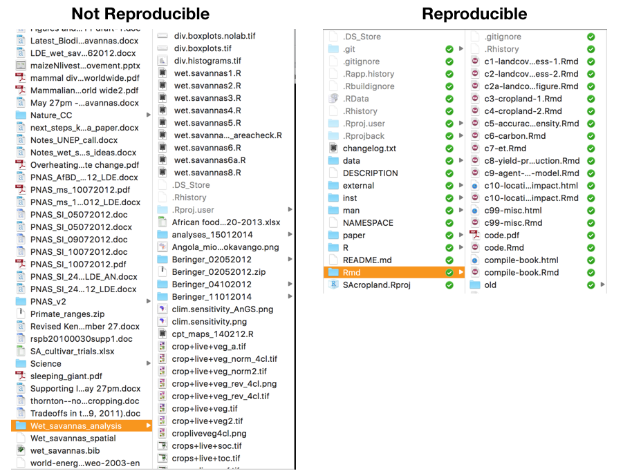

## Reproducibility 2

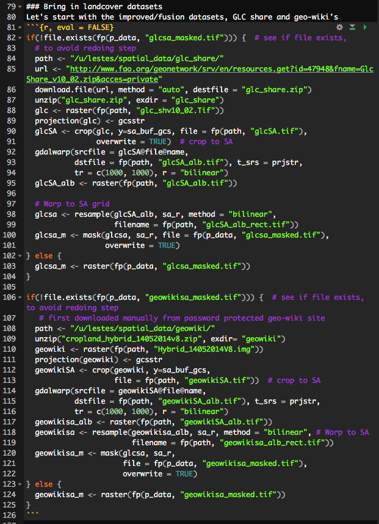

## Course Requirements

- Let’s have a look at the Syllabus
- Basic policies
  - Attendance and communication
  - Attention to detail
  - You are responsible for learning the material

## Projects

- Projects page

## Getting Set Up/Homework

- [README](https://github.com/agroimpacts/geospaar)
- Get yourself a GitHub account, if you haven’t
- Send us your GitHub name (**!!**)
- Install all necessary software on your local computer(s).
- Set up your [personal access token](https://agroimpacts.github.io/geospaar/git-github.html)
- **Read** Unit1-Module 1 before section 3.2.1, section 1.7 Style in Syllabus, and cheatsheet of RStudio and R markdown.